# env_lab_3

Joshua Driscoll

9/22/2021

# Environmental Code

```r
require(psych)
require(here)
dat_bird <- read.csv(here("data", "bird.sta.csv"))
dat_habitat <- read.csv(here("data", "hab.sta.csv"))
dat_all <- merge(dat_bird, dat_habitat)

# Function to calculate the logistic parameter a given the slope and midpoint
get_logistic_param_a = function(slope, midpoint)
{
  b = slope / 4
  return (-midpoint * (slope / 4))
}

# Function to calculate the logistic parameter b given the slope
get_logistic_param_b = function(slope)
{
  return (slope / 4)
}


# Calculate the value of the logistic function at x, given the parameters a and b.
logistic = function(x, a, b)
{
  val = exp(a + b * x)
  return(val / (1 + val))
}

# Calculate the value of the logistic function at x, given a slope and midpoint.
logistic_midpoint_slope = function(x, midpoint, slope)
{
  b = get_logistic_param_b(slope)
  a = get_logistic_param_a(slope, midpoint)
  return(logistic(x, a, b))
}
```

# Q1

Basal area refers to the basal area of trees (both alive/dead) in the study area and it is measured in square meters per hectare (m2/ha)

# Q2

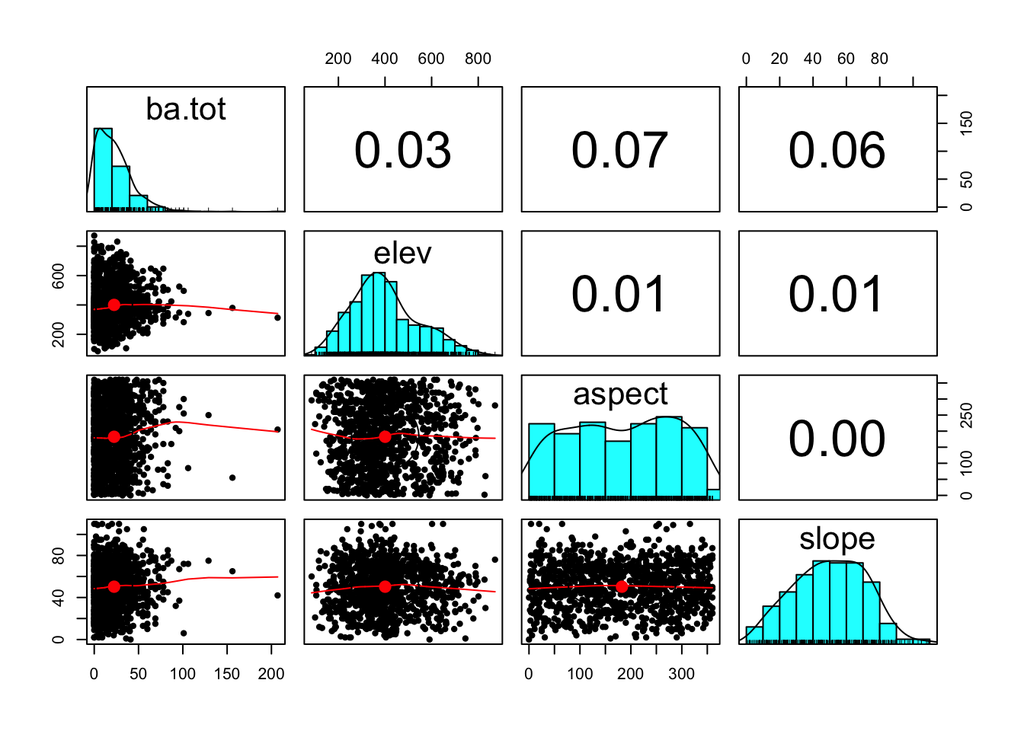

```r
# Terrain Variables
lab_dat <- c(dat_habitat$ba.tot, dat_habitat$elev, dat_habitat$slope, dat_habitat$aspect)
pairs.panels(dat_all[c("ba.tot", "elev", "aspect", "slope")])
```

# Q3

```r
#Wood Duck Pres/Abs
wodu_present_absent <- dat_bird$WODU >= 1
as.numeric(wodu_present_absent)
```

[output not shown]

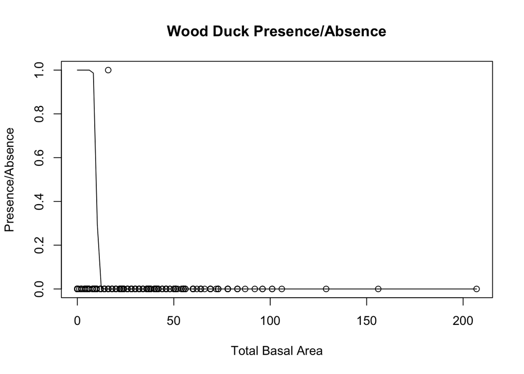

```r
plot(x = dat_habitat$ba.tot, y = wodu_present_absent, main = "Wood Duck Presence/Absence", xlab = "Total Basal Area", ylab = "Presence/Absence")
curve(logistic_midpoint_slope(x, midpoint = 10, slope = -10), add = TRUE)
```

# Q4

Wood duck presence absence does not seem to be correlated with Presence/Absence. Given that there was only one presence recorded of Wood Duck, it would be really hard to make any statement of correlation. Since there was only one presence, I gave my curve a slope of -10 so that it goes down to the x axis very quickly to align with the concentration of absences. I think the logistic model is a decent fit to the data.

# Q5

```r
#Wrentit pres/abs
wrentit_present_absent <- dat_bird$WREN >= 1
as.numeric(wrentit_present_absent)
```

[output not shown]

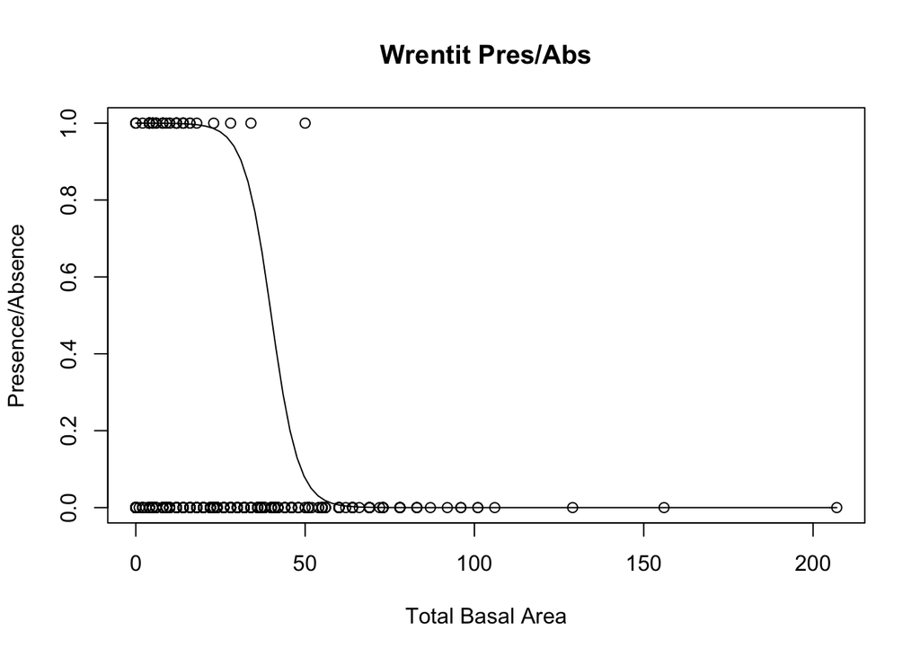

```r
plot(x = dat_habitat$ba.tot, y = wrentit_present_absent, main = "Wrentit Pres/Abs", xlab = "Total Basal Area", ylab = "Presence/Absence")
curve(logistic_midpoint_slope(x, midpoint = 40, slope = -1), add = TRUE)
```

# Q6

Wrentits seem to prefer areas that have <50 m2/hectare with only one 1 observation outside of this limit. To reflect this, my logistic curve has a midpooint of 40 and a relatively steep slope of -1. This logistic model seems like a good fit.

# Q7

There were 181 gray jay seen across study sites

# Q8

```r
grayjay_present_absent <- dat_all$GRJA
sum(grayjay_present_absent)
```

```
## [1] 181
```

# Q9

Gray Jay were seen at a total of 110 sampling sites.

# Q10

```r
boo_grayjay <- dat_all$GRJA >= 1
as.numeric(boo_grayjay)
```

[output not shown]

```r
sum(boo_grayjay)
```

```
## [1] 110
```